# Fit DFA to Ichthyo Abundance

Kristin Marshall

October 23, 2017

This document contains the code and plots for fitting a DFA to the ichthyo. abundance data. The sections below step through model fitting and model selection procedure, show how I fit various covariates, and plots DFA fits and common trends. I also included a cluster analysis that groups species based on their loadings values, and a plot that summarizes those results. I call out in the text figures 2-4 included in the final manuscript.

## Fit the DFA models

```r
cntl.list = list(minit=200, maxit=3000, allow.degen=FALSE)
# set up forms of R matrices
levels.R = c("diagonal and equal",
             "diagonal and unequal",
             "equalvarcov")

model.data=data.frame()
for (j in 2:3){
  for (i in 1:3){

    model.list = list(m=i, R=levels.R[j])
    kemz = MARSS(dat.abund, model=model.list, control=cntl.list,
                 z.score=TRUE, form="dfa")

    model.data = rbind(model.data,
                       data.frame(R=levels.R[j],
                                  m=i,
                                  logLik=kemz$logLik,
                                  K=kemz$num.params,
                                  AICc=kemz$AICc,
                                  converg=kemz$convergence,
                                  stringsAsFactors=FALSE))

    assign(paste("kemz", i, levels.R[j], sep="."), kemz)


  }
}

###################################################
### makemodeltable
###################################################
# calculate delta-AICc
model.data$delta.AICc = model.data$AICc - min(model.data$AICc)
# calculate Akaike weights
wt = exp(-0.5*model.data$delta.AICc)
model.data$Ak.wt = wt/sum(wt)
# sort results
model.tbl = model.data[order(model.data$AICc),-4]
# drop AICc from table
# calculate cumulative wts
model.tbl$Ak.wt.cum = cumsum(model.tbl$Ak.wt)

print(model.tbl)

write.csv(model.tbl,'../data/AbundDFA_AIC.csv')
```

We output the model table here to show that the best-fit model is a two trend model with a covariance matrix with a single parameter on the diagonal, and a second parameter on the diagonal (equalvarcov).

[output not shown]

## Fit DFA models with covariates

The next step is to see if we can improve the model fit by adding explanatory covariates. We looked at three types of covariates: environmental indices, an index for the EVOS spill year, spawning stock biomasses of pollock, pcod, and arrowtooth. The take-home was that none of these covariates improved the AICc over the two trend model. I output the code below.

### Environmental covariates

First, let’s look at the environmental covariates. We looked for relationships with SST, ENSO, NPGO, PDO, NPI, and Upwelling.

```r
temp=read.csv('../data/SSTcovar.csv', header=T)
climate=read.csv('../data/ClimateCovars.csv',header=T)
asst=temp$asst[1:33]
wsst=temp$wsst[1:33]
enso=climate$ENSO[7:39]
npgo=climate$NPGO[7:39]
npi=climate$NPI[7:39]
pdo=climate$PDO[7:39]
up=climate$Upwelling[7:39]

model.list = list(m=2, R="equalvarcov")
cntl.list=list(minit=200, maxit=5000, allow.degen=FALSE)
kemz.no= MARSS(dat.abund, model=model.list, control=cntl.list,
               z.score=TRUE, form="dfa")
kemz.2.asst = MARSS(dat.abund, model=model.list, control=cntl.list,
               z.score=TRUE, form="dfa", covariates=asst)
kemz.2.wsst=MARSS(dat.abund, model=model.list, control=cntl.list,
                z.score=TRUE, form="dfa", covariates=wsst)
kemz.2.enso=MARSS(dat.abund, model=model.list, control=cntl.list,
                z.score=TRUE, form="dfa", covariates=enso)
kemz.2.npgo=MARSS(dat.abund, model=model.list, control=cntl.list,
                z.score=TRUE, form="dfa", covariates=npgo)
kemz.2.npi=MARSS(dat.abund, model=model.list, control=cntl.list,
                z.score=TRUE, form="dfa", covariates=npi)
kemz.2.pdo=MARSS(dat.abund, model=model.list, control=cntl.list,
                z.score=TRUE, form="dfa", covariates=pdo)
kemz.2.up=MARSS(dat.abund, model=model.list, control=cntl.list,
                z.score=TRUE, form="dfa", covariates=up)

env.out=cbind(model=c("no covars", "AnnTemp", "WinTemp","ENSO","NPGO","NPI","PDO","Upwelling"),
            AICc=round(c(kemz.no$AICc, kemz.2.asst$AICc, kemz.2.wsst$AICc, kemz.2.enso$AICc,
                         kemz.2.npgo$AICc, kemz.2.npi$AICc, kemz.2.pdo$AICc,kemz.2.up$AICc)))
print(env.out, quote=F)

# model     AICc
#[1,] no covars 3261
#[2,] AnnTemp   3354
#[3,] WinTemp   3355
#[4,] ENSO      3313
#[5,] NPGO      3305
#[6,] NPI       3354
#[7,] PDO       3301
#[8,] Upwelling 3312
```

From this table, we conclude that none of the climate cocariates improved the model fit over a 2 trend model.

Similarly, we might want to know if adding these covariates to a one trend model improves the fit.

```r
model.list = list(m=1, R="equalvarcov")
cntl.list=list(minit=200, maxit=5000, allow.degen=FALSE)
kemz.1.no= MARSS(dat.abund, model=model.list, control=cntl.list,
               z.score=TRUE, form="dfa")
kemz.1.asst = MARSS(dat.abund, model=model.list, control=cntl.list,
               z.score=TRUE, form="dfa", covariates=asst)
kemz.1.wsst=MARSS(dat.abund, model=model.list, control=cntl.list,
                z.score=TRUE, form="dfa", covariates=wsst)
kemz.1.enso=MARSS(dat.abund, model=model.list, control=cntl.list,
                z.score=TRUE, form="dfa", covariates=enso)
kemz.1.npgo=MARSS(dat.abund, model=model.list, control=cntl.list,
                z.score=TRUE, form="dfa", covariates=npgo)
kemz.1.npi=MARSS(dat.abund, model=model.list, control=cntl.list,
                z.score=TRUE, form="dfa", covariates=npi)
kemz.1.pdo=MARSS(dat.abund, model=model.list, control=cntl.list,
                z.score=TRUE, form="dfa", covariates=pdo)
kemz.1.up=MARSS(dat.abund, model=model.list, control=cntl.list,
                z.score=TRUE, form="dfa", covariates=up)

env.1.out=cbind(model=c("no covars", "AnnTemp", "WinTemp","ENSO","NPGO","NPI","PDO","Upwelling"),
            AICc=round(c(kemz.1.no$AICc, kemz.1.asst$AICc, kemz.1.wsst$AICc, kemz.1.enso$AICc,
                         kemz.1.npgo$AICc, kemz.1.npi$AICc, kemz.1.pdo$AICc,kemz.1.up$AICc)))

print(env.1.out, quote=FALSE)

#model     AICc
#no covars 3280
#[2,] AnnTemp   3369
# [3,] WinTemp   3369
# [4,] ENSO      3328
# [5,] NPGO      3321
# [6,] NPI       3369
# [7,] PDO       3321
# [8,] Upwelling 3328
```

We conclude that including environmental covariates do not improve the one trend model, either.

### Fit SSB covariates

Next, we try it for pollock, pcod, and arrowthooth, for both the 1 trend and 2 trend models.

```r
SSB=read.csv('../data/ssbout.csv', header=T)
#ind=which(SSB$Year >1980 & SSB$Year<2014)
poll=SSB$V2/10^5
pcod=SSB$V3[ind]/10^5
arrtooth=SSB$V5[ind]/10^6

model.list = list(m=2, R="equalvarcov")
cntl.list=list(minit=200, maxit=5000, allow.degen=FALSE)
kemz.2.no= MARSS(dat.abund, model=model.list, control=cntl.list,
               z.score=TRUE, form="dfa")
kemz.2.poll = MARSS(dat.abund, model=model.list, control=cntl.list,
               z.score=TRUE, form="dfa", covariates=poll)
kemz.2.pcod=MARSS(dat.abund, model=model.list, control=cntl.list,
                z.score=TRUE, form="dfa", covariates=pcod)
kemz.2.arr=MARSS(dat.abund, model=model.list, control=cntl.list,
                z.score=TRUE, form="dfa", covariates=arrtooth)

ssb2.out=cbind(model=c("2 trend", "2.Pollock", "2.Pcod","2.Arrowtooth"),
            AICc=round(c(kemz.2.no$AICc, kemz.2.poll$AICc, kemz.2.pcod$AICc, kemz.2.arr$AICc)))


model.list = list(m=1, R="equalvarcov")
cntl.list=list(minit=100, maxit=5000, allow.degen=FALSE)
kemz.1.no= MARSS(dat.abund, model=model.list, control=cntl.list,
               z.score=TRUE, form="dfa")
kemz.1.poll = MARSS(dat.abund, model=model.list, control=cntl.list,
               z.score=TRUE, form="dfa", covariates=poll)
kemz.1.pcod=MARSS(dat.abund, model=model.list, control=cntl.list,
                z.score=TRUE, form="dfa", covariates=pcod)
kemz.1.arr=MARSS(dat.abund, model=model.list, control=cntl.list,
                z.score=TRUE, form="dfa", covariates=arrtooth)

ssb1.out=cbind(model=c("1 trend", "1.Pollock", "1.Pcod","1.Arrowtooth"),
            AICc=round(c(kemz.1.no$AICc, kemz.1.poll$AICc, kemz.1.pcod$AICc, kemz.1.arr$AICc)))


print(ssb1.out, quote=FALSE)
# model        AICc
# [1,] 1 trend      3280
# [2,] 1.Pollock    3362
# [3,] 1.Pcod       3361
# [4,] 1.Arrowtooth 3367
print(ssb2.out, quote=FALSE)
```

None of the SSB indices helped model fit, and many didn’t converge with the 2 trend model.

### Fit oil spill covariate

Last, we want to know if there is support for the year of the spill being anamolous. So, we creates a covariate for spill year, which is 0 in every year except 1989, in that year it’s -1. Then we ask if that improves the model fit.

```r
spill=rep(0,33)
spill[9]=-1

model.list = list(m=1, R="equalvarcov")
cntl.list=list(minit=200, maxit=5000, allow.degen=FALSE)
kemz.1.no= MARSS(dat.abund, model=model.list, control=cntl.list,
               z.score=TRUE, form="dfa")
kemz.1.oil = MARSS(dat.abund, model=model.list, control=cntl.list,
                  z.score=TRUE, form="dfa", covariates=spill)
model.list = list(m=2, R="diagonal and equal")
kemz.2.no= MARSS(dat.abund, model=model.list, control=cntl.list,
               z.score=TRUE, form="dfa")
kemz.2.oil = MARSS(dat.abund, model=model.list, control=cntl.list,
                  z.score=TRUE, form="dfa", covariates=spill)

print(cbind(model=c("1 trend", "1 trend + oil", "2 trend","2 trend + oil"),
            AICc=round(c(kemz.1.no$AICc, kemz.1.oil$AICc, kemz.2.no$AICc, kemz.2.oil$AICc))), quote=FALSE)
```

## Best fit DFA

[figure not shown]

[figure not shown]

## Indices of Abundance

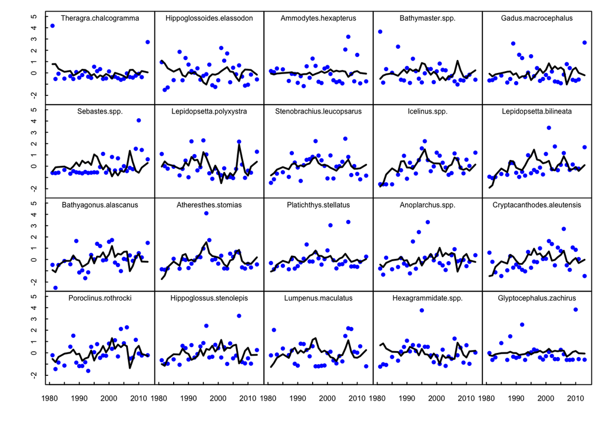

```r
#pdf("plots/AppB.RawAbund.pdf")
par(mfrow=c(4,5), mar=c(0,0,0,0), oma=c(4,4,1,1))
par(mgp = c(.6, .6, 0))
par(tcl=.2)
for(i in 1:length(spp)){
  plot(years.plot,dat.z[i,],xlab="",ylab="Index", bty="L", pch=16, col="blue",
       ylim=c(min(dat.z, na.rm=T),max(dat.z, na.rm=T)), xlim=c(1980,2014),axes=F)
  par.mat=coef(fit,type="matrix")
  lines(years.plot,as.vector(par.mat$Z[i,,drop=FALSE]%*%fit$states+par.mat$A[i,]), lwd=2)
  if(i %in% c(16:20,36:40)) axis(1,at=seq(1980,2010, by=5), cex.axis=0.8)
  if(i %in% c(1,6,11,16, 21, 26, 31,36)) axis(2, at=seq(-2,5, by=1), cex.axis=0.8)
  box()
  mtext(spp[i], side=3, line=-1, cex=0.5)
}
```

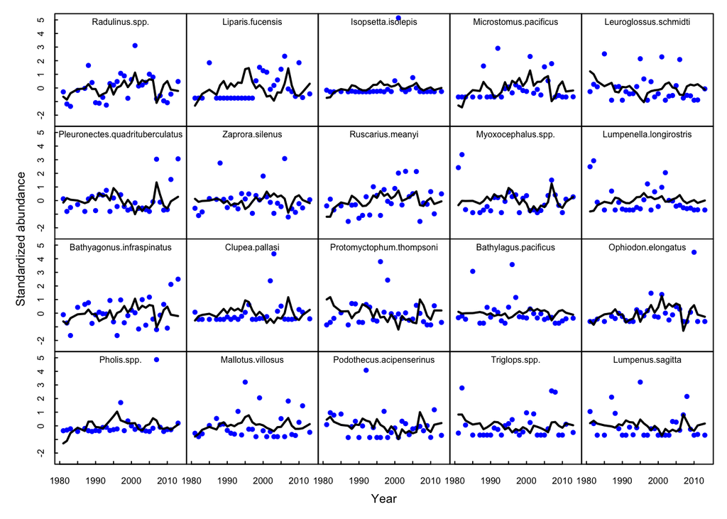

```r
mtext("Year", side=1, outer=TRUE, line=2, cex=0.7)
mtext("Standardized abundance", side=2, outer=TRUE, line=2, cex=0.7)
```

In addition to looking at the fits, we want to look at the common **trends** and **loadings**. Before we can do that, we need to rotate the trends and loadings to make them as orthogonal as possible.

```r
best.fit=kemz.2
###################################################
### varimax
###################################################
# get the inverse of the rotation matrix
H.inv = varimax(coef(best.fit, type="matrix")$Z)$rotmat


###################################################
### rotations
###################################################
Z.no.rot=coef(best.fit, type="matrix")$Z
# rotate factor loadings
Z.rot = coef(best.fit, type="matrix")$Z %*% H.inv

##use this if only a 1-trend model
#Z.rot=coef(best.fit, type="matrix")$Z


# rotate trends
trends.rot = solve(H.inv) %*% best.fit$states

##use this if only a 1-trend model
#trends.rot=best.fit$states
trends.no.rot=best.fit$states
```

Now, we can plot the rotated trends. The trend plot is **Figure 3**.

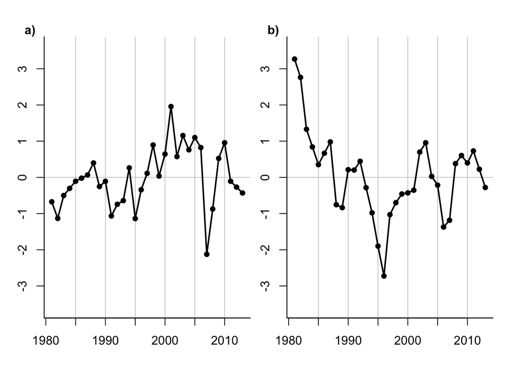

We can also calculate the proportion of variance explained by the full model, using sum of squared errrors.

```r
##rsquared
pred = Z.no.rot %*% trends.no.rot
SSres = sum((pred - dat.z) ^ 2, na.rm=T)
SStot = sum((mean(dat.z, na.rm=T) - dat.z) ^ 2, na.rm=T)
R2 = 1 - SSres / SStot
print(R2)
```

```
## [1] -0.02200167
```

Now, let’s look at how the individual species group together, based on their loadings on the common trends. We can then make a bivariate plot of the loadings, showing the four different groups using different colored text. This plot is **Figure 4**.

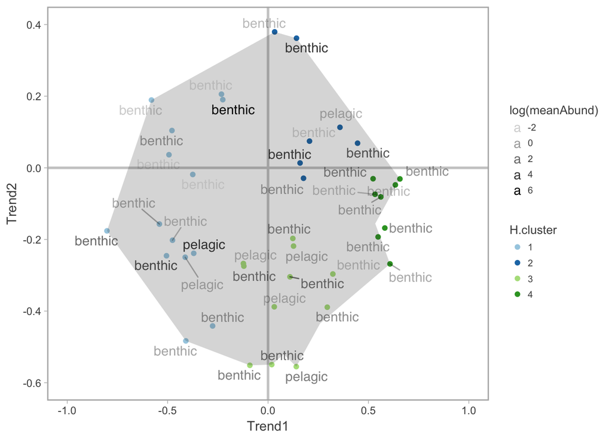

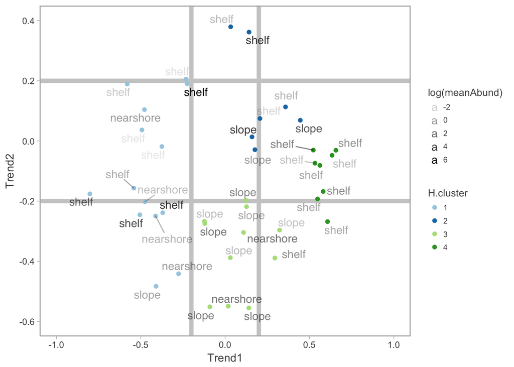

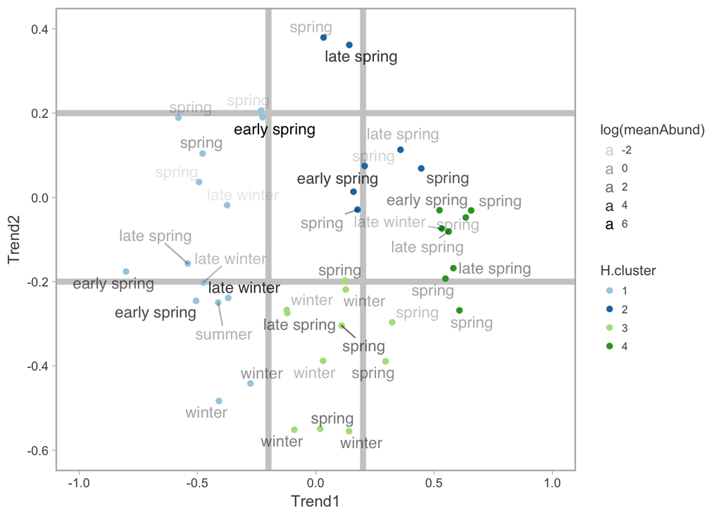

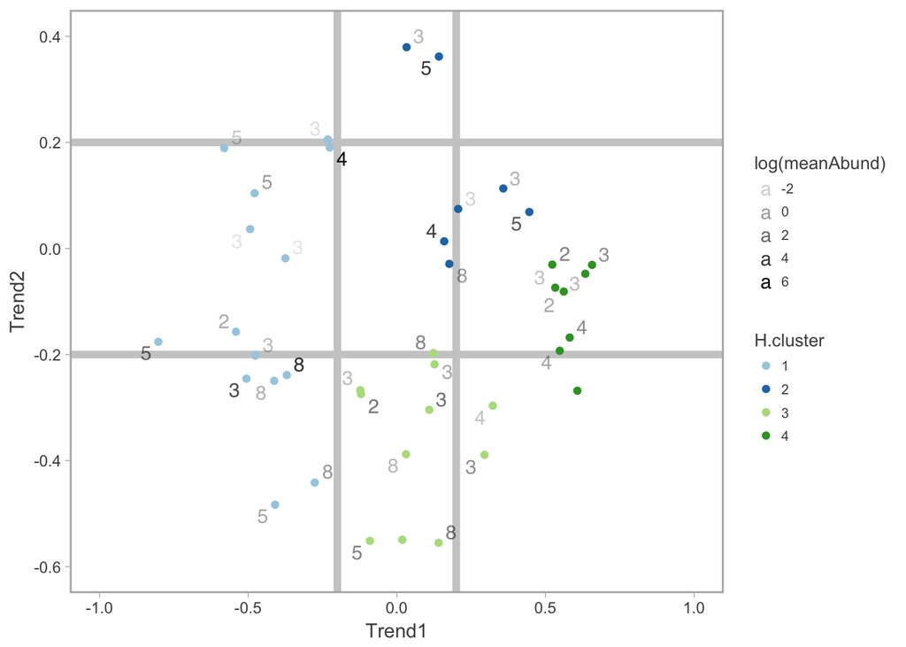

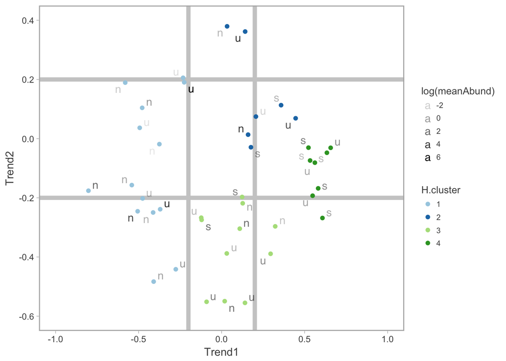

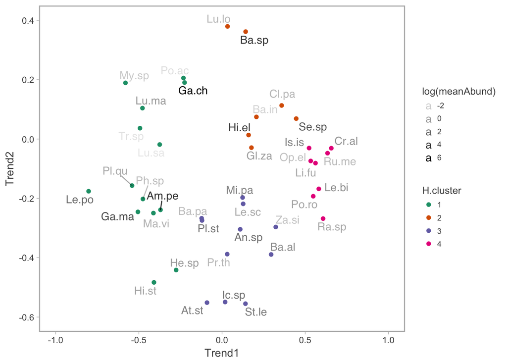